# Aula 7 - Econometria de Séries Temporais

Autor

João Ricardo F. de Lima

Data de Publicação

30 de abril de 2025

# Co-Integração

A regressão de uma série temporal não estacionária contra outra série temporal não estacionária pode produzir uma regressão espúria, também chamada de regressão sem sentido. Contudo, existe uma exceção a essa regra. Considere duas séries não estacionárias e integradas de mesma ordem, $Y_t$ e $X_t$ e uma relação linear entre elas dada por

$$Y_t=\beta X_t + \epsilon_t$$

Se existir algum valor de $\beta$ tal que $Y_t-\beta X_t$ seja I(0), mesmo com as séries originais não sendo estacionárias, a regressão é considerada não espúria.

Neste caso, as séries são ditas cointegradas e compartilham a mesma tendência. Dito de outra forma, o que se obteve foi uma combinação linear de duas séries I(d) que gerou um nova série com menor ordem de integração.

Sobre as propriedades das séries cointegradas:

1. se $X_t \sim I(d)$ e $Y_t \sim I(d)$, então, $Z_t=aX_t+bY_t \sim I(d^*)$;
2. $d^*$ em geral é igual a d, mas em alguns casos $d^* \leq d$.

Como exemplo, considere concessões mensais de crédito e a taxa média de juros, com base no post da Analise Macro (https://analisemacro.com.br/economia/indicadores/relatorio-38-analise-de-dados-de-credito-no-r/).

A idéia é estimar o modelo abaixo para verificar se a regressão é espúria ou se um modelo de correção de erro deve ser estimado.

$$Y_t=\beta_0+\beta_1X_t+u_t$$

em que $Y_t$ é a concessão mensal de crédito, $X_t$ é a taxa média de juros e $u_t$ é o vetor de resíduos.

Inicialmente serão usados os **correlogramas** para tentar identificar se a série é ou não é estacionária.

## Entrada de dados no R

```r
# Carregar pacotes/dependências
# Carregar pacotes
library(GetBCBData)
library(magrittr)
library(dplyr)
library(ggplot2)
library(scales)
library(tidyr)
library(deflateBR)
library(lubridate)
library(ggseas)
library(stringr)
library(zoo)
library(forecast)

## Funções e objetos úteis

# Cores para gráficos e tabelas
colors <- c(
blue = "#282f6b",
red = "#b22200"
)

# Fonte para gráficos e tabelas
foot_ibge <- "Dados do BCB."

# Definir padrão de gráficos
ggplot2::theme_set(
theme(
plot.title = ggplot2::element_text(size = 15, hjust = 0, vjust = 2)
)
)

## Parâmetros e códigos para coleta de dados
parametros <- c(
# Concessões de crédito - Total - R$ (milhões)
"Concessões de crédito - Total" = 20631,

# Concessões de crédito - Pessoas jurídicas - Total - R$ (milhões)
"Concessões de crédito - PJ" = 20632,

# Concessões de crédito - Pessoas físicas - Total - R$ (milhões)
"Concessões de crédito - PF" = 20633,

# Taxa média de juros das operações de crédito - Total - % a.a.
"Taxa média de juros das operações de crédito" = 20714
)

## Coleta dos dados

# Dados do BCB (tidy)
raw_dados <- GetBCBData::gbcbd_get_series(
id = parametros,
first.date = "2013-01-01",
last.date = "2020-12-01",
use.memoise = FALSE
)

glimpse(raw_dados)
```

```
Rows: 384
Columns: 4
$ ref.date    <date> 2013-01-01, 2013-02-01, 2013-03-01, 2013-04-01, 2013-05-0…
$ value       <dbl> 239834, 226768, 253830, 269990, 285961, 278819, 266075, 27…
$ id.num      <dbl> 20631, 20631, 20631, 20631, 20631, 20631, 20631, 20631, 20…
$ series.name <chr> "Concessões de crédito - Total", "Concessões de crédito - …
```

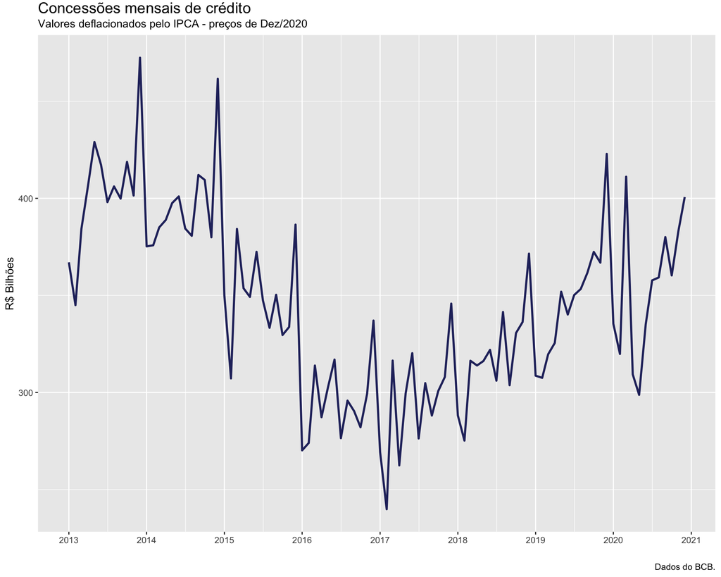

```r
## Tratamento dos dados

# Dados tratados em formato long
dados <- raw_dados %>%
dplyr::select(
"date" = ref.date,
"variable" = series.name,
value
)

# Deflacionar variáveis selecionadas (concessões)
concessoes <- dados  %>%
dplyr::filter(
variable %in% c(
"Concessões de crédito - Total",
"Concessões de crédito - PJ",
"Concessões de crédito - PF"
)
)  %>%
tidyr::pivot_wider(
id_cols = date,
names_from = variable,
values_from = value
)  %>%
dplyr::mutate(
dplyr::across(
-date,
~deflateBR::deflate( # deflacionar séries com o IPCA
nominal_values = .,
nominal_dates = date %m+% months(1),
real_date = format(tail(date, 1), "%m/%Y"),
index = "ipca"
)
)
)  %>%
tidyr::pivot_longer(
cols = -date,
names_to = "variable",
values_to = "value"
)

concessoes %>%
dplyr::filter(variable == "Concessões de crédito - Total")  %>%
ggplot2::ggplot(ggplot2::aes(x = date, y = value/1000)) +
ggplot2::geom_line(size = 1, colour = unname(colors[1])) +
ggplot2::labs(
x = "",
y = "R$ Bilhões",
title = "Concessões mensais de crédito",
subtitle = paste0(
"Valores deflacionados pelo IPCA - preços de ",
format(tail(concessoes$date, 1), "%b/%Y")
),
caption = foot_ibge) +
ggplot2::scale_x_date(
breaks = scales::date_breaks("1 year"),
labels = scales::date_format("%Y")
)
```

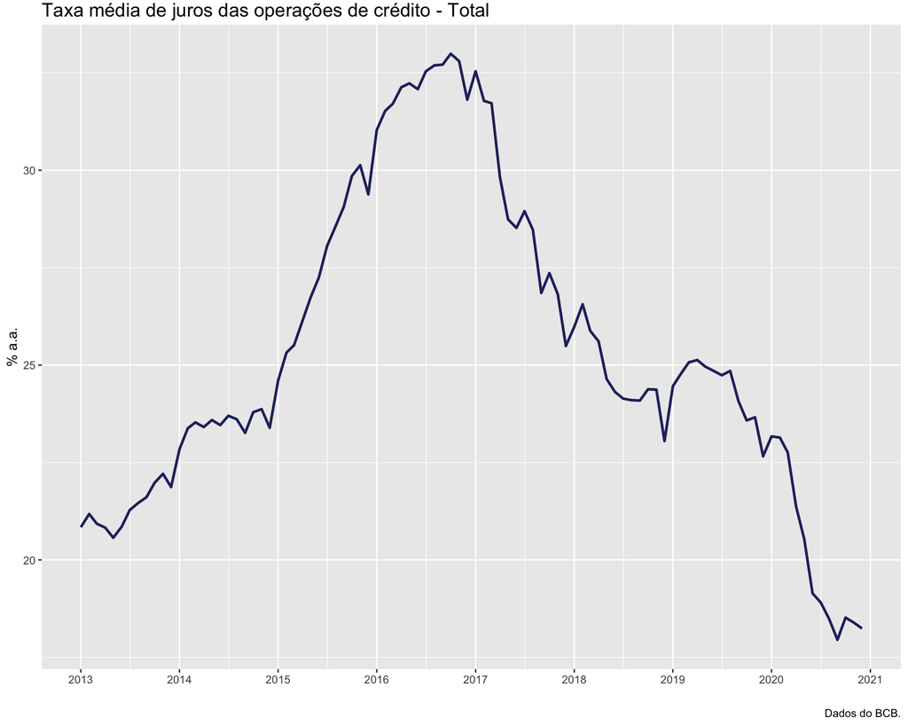

```r
dados %>%
dplyr::filter(variable == "Taxa média de juros das operações de crédito") %>%
ggplot2::ggplot(ggplot2::aes(x = date, y = value)) +
ggplot2::geom_line(size = 1, colour = unname(colors[1])) +
ggplot2::labs(
x = "",
y = "% a.a.",
title = "Taxa média de juros das operações de crédito - Total",
caption = foot_ibge) +
ggplot2::scale_x_date(
breaks = scales::date_breaks("1 year"),
labels = scales::date_format("%Y")
)
```

## Gráfico das séries, FAC e FACp

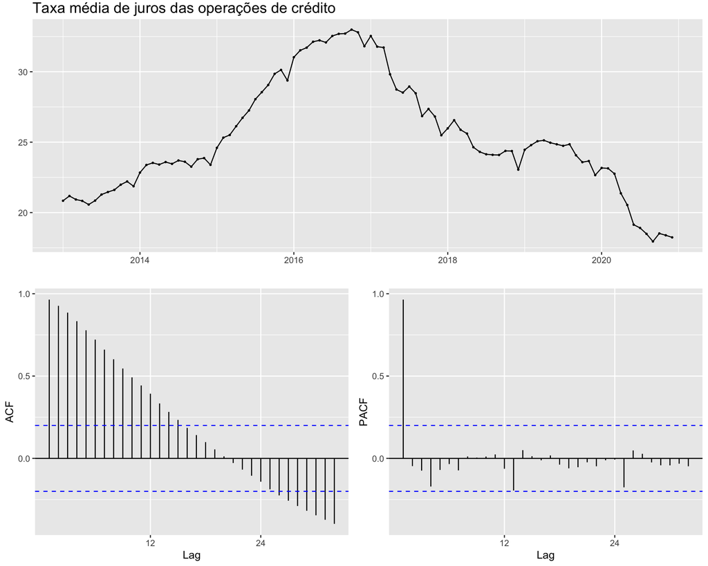

```r
juros <- dados %>%
dplyr::filter(variable == "Taxa média de juros das operações de crédito")
juros <- juros[,3]
juros <- ts(juros, start = c(2013,1), freq=12)

credito <- concessoes %>%
dplyr::filter(variable == "Concessões de crédito - Total")
# execução do ajuste no modo automático
credito <- credito[,3]
credito <- ts(credito, start = c(2013,1), freq=12)
decomp <- decompose(credito/1000)
credito_seas <- credito/1000 - decomp$seasonal

#Correlograma das series
ggtsdisplay(juros, main='Taxa média de juros das operações de crédito')
```

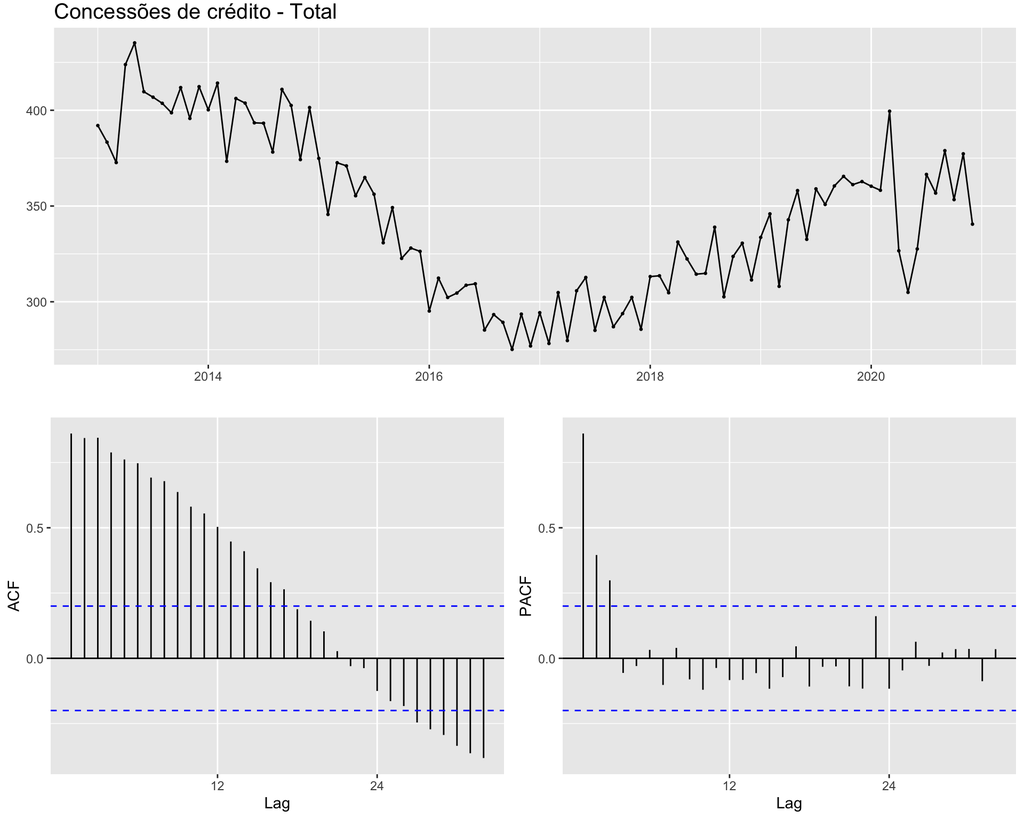

```r
ggtsdisplay(credito_seas, main='Concessões de crédito - Total')
```

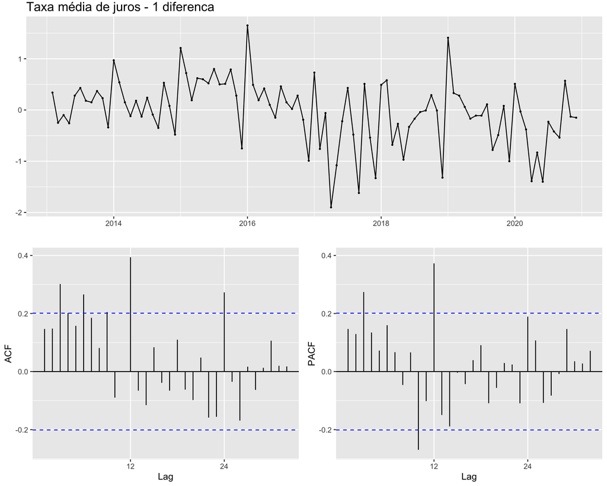

```r
#Diferenciacao da Serie
djuros <- diff(juros, differences = 1)
dcredito <- diff(credito_seas, differences = 1)

#Visualizando Correlogramas na 1 Diferenca
ggtsdisplay(djuros, main='Taxa média de juros - 1 diferenca')
```

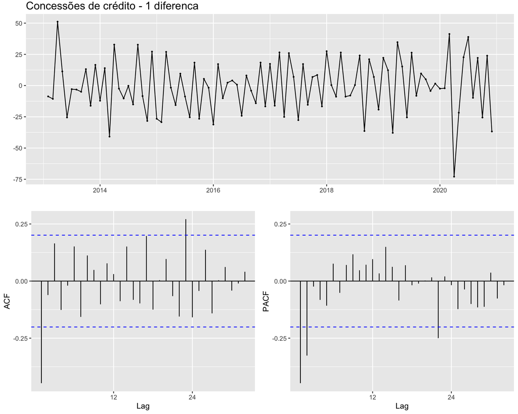

```r
ggtsdisplay(dcredito, main='Concessões de crédito - 1 diferenca')
```

## Teste de Raiz Unitária DFGLS

O resultado do teste DF-GLS, na primeira diferença, com constante é:

```r
library(urca)
#Analise dos testes de raiz unitaria em nivel
#Definicao do numero maximo de lags
print(12*(length(juros)/100)^(1/4))
```

```
[1] 11.87816
```

```r
print(12*(length(credito_seas)/100)^(1/4))
```

```
[1] 11.87816
```

```r
#Estatistica de Teste DFGLS para DCP na 1 Diferença

djurosc.dfgls <- ur.ers(djuros, type = c("DF-GLS"),
                     model = c("constant"),
                     lag.max = 2)
summary(djurosc.dfgls)
```

```
###############################################
# Elliot, Rothenberg and Stock Unit Root Test #
###############################################

Test of type DF-GLS
detrending of series with intercept


Call:
lm(formula = dfgls.form, data = data.dfgls)

Residuals:
     Min       1Q   Median       3Q      Max
-2.10266 -0.40052 -0.02359  0.24419  1.41179

Coefficients:
             Estimate Std. Error t value Pr(>|t|)
yd.lag        -0.4215     0.1364  -3.089 0.002679 **
yd.diff.lag1  -0.4475     0.1278  -3.501 0.000727 ***
yd.diff.lag2  -0.3151     0.1008  -3.127 0.002387 **
---
Signif. codes:  0 '***' 0.001 '**' 0.01 '*' 0.05 '.' 0.1 ' ' 1

Residual standard error: 0.6241 on 89 degrees of freedom
Multiple R-squared:  0.4626,    Adjusted R-squared:  0.4445
F-statistic: 25.53 on 3 and 89 DF,  p-value: 5.217e-12


Value of test-statistic is: -3.089

Critical values of DF-GLS are:
                 1pct  5pct 10pct
critical values -2.59 -1.94 -1.62
```

```r
#Estatistica de Teste DFGLS para RPD na 1 Diferença
dcreditoc.dfgls <- ur.ers(dcredito, type = c("DF-GLS"),
                     model = c("constant"),
                     lag.max =2)
summary(dcreditoc.dfgls)
```

```
###############################################
# Elliot, Rothenberg and Stock Unit Root Test #
###############################################

Test of type DF-GLS
detrending of series with intercept


Call:
lm(formula = dfgls.form, data = data.dfgls)

Residuals:
    Min      1Q  Median      3Q     Max
-51.451  -3.544   7.002  18.199  72.720

Coefficients:
             Estimate Std. Error t value Pr(>|t|)
yd.lag       -1.05085    0.21241  -4.947 3.53e-06 ***
yd.diff.lag1 -0.26977    0.16533  -1.632   0.1063
yd.diff.lag2 -0.25686    0.09992  -2.571   0.0118 *
---
Signif. codes:  0 '***' 0.001 '**' 0.01 '*' 0.05 '.' 0.1 ' ' 1

Residual standard error: 20.44 on 89 degrees of freedom
Multiple R-squared:  0.6972,    Adjusted R-squared:  0.687
F-statistic: 68.31 on 3 and 89 DF,  p-value: < 2.2e-16


Value of test-statistic is: -4.9473

Critical values of DF-GLS are:
                 1pct  5pct 10pct
critical values -2.59 -1.94 -1.62
```

As duas séries possuem raiz unitária em nível, mas são estacionárias na primeira diferença, ou seja, são I(1). Então, as duas séries são integradas de mesma ordem. Se a combinação linear entre as duas for estacionário, elas serão cointegradas. Isto significa que existe uma relação de longo prazo entre elas.

Resultado da regressão estimada:

```r
#Estimacao do Modelo DCP em funcao da RPD
regressao1 <- lm(credito_seas ~ juros)
summary(regressao1)
```

```
Call:
lm(formula = credito_seas ~ juros)

Residuals:
    Min      1Q  Median      3Q     Max
-74.709 -21.393   1.818  25.106  55.772

Coefficients:
            Estimate Std. Error t value Pr(>|t|)
(Intercept) 527.8467    20.0595  26.314  < 2e-16 ***
juros        -7.2159     0.7822  -9.225 8.19e-15 ***
---
Signif. codes:  0 '***' 0.001 '**' 0.01 '*' 0.05 '.' 0.1 ' ' 1

Residual standard error: 30.56 on 94 degrees of freedom
Multiple R-squared:  0.4751,    Adjusted R-squared:  0.4696
F-statistic:  85.1 on 1 and 94 DF,  p-value: 8.185e-15
```

o aumento dos juros reduz a concessão de crédito no longo prazo.

Os resíduos desta regressão podem ser submetidos a um teste de raiz unitária.

## Análise dos resíduos

```r
#Salvando os residuos da regressao
resid1 <- regressao1$residuals

#Teste de raiz unitaria nos residuos
resid.dfgls <- ur.ers(resid1, type = c("DF-GLS"),
                      model = c("constant"),
                      lag.max = 1)
summary(resid.dfgls)
```

```
###############################################
# Elliot, Rothenberg and Stock Unit Root Test #
###############################################

Test of type DF-GLS
detrending of series with intercept


Call:
lm(formula = dfgls.form, data = data.dfgls)

Residuals:
    Min      1Q  Median      3Q     Max
-68.502 -13.056  -0.705  11.624  43.973

Coefficients:
             Estimate Std. Error t value Pr(>|t|)
yd.lag       -0.13560    0.07007  -1.935   0.0561 .
yd.diff.lag1 -0.40474    0.09843  -4.112 8.51e-05 ***
---
Signif. codes:  0 '***' 0.001 '**' 0.01 '*' 0.05 '.' 0.1 ' ' 1

Residual standard error: 19.38 on 92 degrees of freedom
Multiple R-squared:  0.2479,    Adjusted R-squared:  0.2315
F-statistic: 15.16 on 2 and 92 DF,  p-value: 2.038e-06


Value of test-statistic is: -1.935

Critical values of DF-GLS are:
                 1pct  5pct 10pct
critical values -2.59 -1.94 -1.62
```

Os resíduos da regressão são estacionários, ou seja, I(0), considerando um nível de significância de 10%. Então, apesar das séries apresentarem tendencias estocásticas, a combinação linear delas (resíduo) é I(0).

O resultado disto é que a regressão passa a ter sentido e dizemos que as duas variáveis são co-integradas, ou seja, existe entre elas uma relação de equilíbrio de longo prazo.

No curto prazo, contudo, pode haver desequilíbrio. Assim, o termo de erro u, obtido da estimativa, pode ser usado para relacionar o comportamento de curto prazo e o do longo prazo. Isto é chamado de **mecanismo de correção de erro**.

Considere o seguinte modelo:

$$\Delta{Y_t}=\alpha_0+\alpha_1 \Delta{X_t}+\alpha_2u_{t-1}+\epsilon_t$$
$\Delta$ indica o operador de diferença; $\epsilon$ um termo de erro aleatório, $Y_t$ é a concessão mensal de crédito, $X_t$ é a taxa média de juros e$u_{t-1}$ é o valor defasado de um período do resíduo da regressão co-integrante.

A equação do mecanismo de correção de erro acima mostra que $\Delta{Y_t}$ depende de $\Delta{X_t}$ e também do termo de erro de equilíbrio;

A estimativa da equação do mecanismo de correção de erro é:

## Estimação do Mecanismo de Correção de Erro no R

```r
#Estimacao do modelo de Correcao de erro
resid1_lag <- stats::lag(resid1,-1)[-length(credito)]
regressao2 <- lm(dcredito ~ djuros + resid1_lag)
summary(regressao2)
```

```
Call:
lm(formula = dcredito ~ djuros + resid1_lag)

Residuals:
    Min      1Q  Median      3Q     Max
-56.109 -12.965   2.045  12.176  50.478

Coefficients:
            Estimate Std. Error t value Pr(>|t|)
(Intercept) -0.25519    2.04077  -0.125    0.901
djuros       3.66585    3.34938   1.094    0.277
resid1_lag  -0.31811    0.07106  -4.476 2.17e-05 ***
---
Signif. codes:  0 '***' 0.001 '**' 0.01 '*' 0.05 '.' 0.1 ' ' 1

Residual standard error: 19.86 on 92 degrees of freedom
Multiple R-squared:  0.179, Adjusted R-squared:  0.1612
F-statistic: 10.03 on 2 and 92 DF,  p-value: 0.0001146
```

Como pode ser observado, a estimativa de u(-1) é negativo. Isto significa que Y está acima do equilíbrio e começará a cair no período seguinte para retornar ao equilíbrio. A interpretação é que 31,81 % da discrepância entre as duas variáveis no mês anterior é eliminado no mês atual.

A interpretação de d(juros) é como o efeito de curto prazo, mas não foi estatisticamente significativo.

# Análise no Python

## Baixar e fazer gráfico das séries

```python
from bcb import sgs
import pandas as pd
import numpy as np
from pathlib import Path
import statsmodels.api as sm
import statsmodels.tsa.api as tsa
from statsmodels.graphics.tsaplots import plot_acf, plot_pacf
from statsmodels.stats.diagnostic import acorr_ljungbox
from statsmodels.stats.stattools import jarque_bera
from statsmodels.tsa.seasonal import seasonal_decompose
import matplotlib.pyplot as plt
from plotnine import *
import plotnine as p9
import seaborn as sns
from arch.unitroot import DFGLS
```

```python
# 1. Define all series
series = {
    'credito_total': 20631,
    'credito_pj': 20632,
    'credito_pf': 20633,
    'juros_medio': 20714,
}

# 2. Download series de credito
raw_dados = sgs.get(series, start='2013-01-01', end='2020-12-01').reset_index()

# Caminho para os arquivos
data_dir = Path("/Users/jricardofl/Dropbox/Facape/2025/20251/Econometria II/econ2_aula7/aula7/data")

# IPCA dados
ipca_table = pd.read_excel(data_dir/'Tabela 1737.xlsx', sheet_name='Tabela', skiprows=3)


# Renomear as columns
ipca_table = ipca_table.rename(columns={
    ipca_table.columns[0]: 'mes',
    ipca_table.columns[1]: 'ipca_index'
})

# Deletar a linha nao numerica
ipca_table = ipca_table[pd.to_numeric(ipca_table['ipca_index'], errors='coerce').notnull()]

# Portugues para ingles
meses_portugues = {
    'janeiro': 'January',
    'fevereiro': 'February',
    'março': 'March',
    'abril': 'April',
    'maio': 'May',
    'junho': 'June',
    'julho': 'July',
    'agosto': 'August',
    'setembro': 'September',
    'outubro': 'October',
    'novembro': 'November',
    'dezembro': 'December'
}

for pt, en in meses_portugues.items():
    ipca_table['mes'] = ipca_table['mes'].str.replace(pt, en, regex=False)

# 2. transforma "mes" em datetime
ipca_table['Date'] = pd.to_datetime(ipca_table['mes'], format='mixed', dayfirst=True, errors='coerce')

# 3. Deleta as linhas que nao funcionou
ipca_table = ipca_table[ipca_table['Date'].notna()]

# 4. Filtra para a data correta igual creditos
# Mantém apenas dados entre jan/2013 e dez/2020
ipca_table = ipca_table[ipca_table['Date'] >= pd.to_datetime('2013-01-01')]
ipca_table = ipca_table[ipca_table['Date'] <= pd.to_datetime('2020-12-01')]

# 5. Checagem
print(ipca_table.head())
```

```
               mes  ipca_index       Date
397   January 2013     3633.44 2013-01-01
398  February 2013     3655.24 2013-02-01
399     March 2013     3672.42 2013-03-01
400     April 2013     3692.62 2013-04-01
401       May 2013     3706.28 2013-05-01
```

```python
# 1. Cria variavel Data_deflate
raw_dados['Date_deflate'] = raw_dados['Date']

# 2. Merge raw_dados com ipca_table
final_data = pd.merge(
    raw_dados,
    ipca_table[['Date', 'ipca_index']],
    left_on='Date_deflate',
    right_on='Date',
    how='left'
)

# 3. Base IPCA index (ultimo disponível)
base_ipca = final_data['ipca_index'].iloc[-1]

# 4. Deflaciona as series
for col in ['credito_total', 'credito_pj', 'credito_pf']:
    final_data[col] = final_data[col] * (base_ipca / final_data['ipca_index'])

# 5. LImpando as colunas e gerando concessoes
final_data = final_data.drop(columns=['Date_y'])
concessoes = final_data.rename(columns={'Date_x': 'Date'})

# 6. Checagem se os dados estao deflacionados
print(concessoes[['Date', 'credito_total', 'credito_pj', 'credito_pf']].head())
```

```
        Date  credito_total     credito_pj     credito_pf
0 2013-01-01  367040.199387  194669.010409  172371.188978
1 2013-02-01  344974.303499  188598.873193  156375.430306
2 2013-03-01  384336.366674  214816.819718  169519.546955
3 2013-04-01  406568.694883  221146.927014  185421.767869
4 2013-05-01  429031.772286  242195.960289  186835.811997
```

## Gráfico do Crédito Total

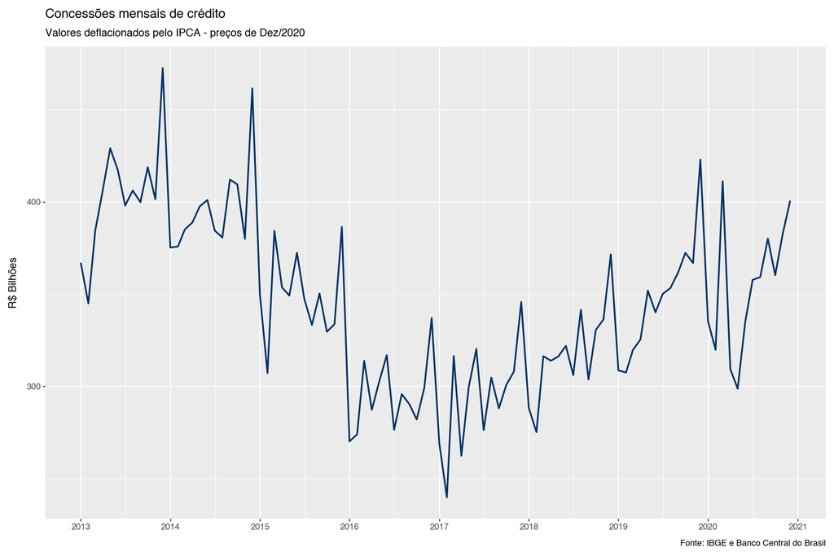

```python
# 1. Grafico para credito_total

plot = (
    p9.ggplot(concessoes) +
    p9.aes(x='Date', y='credito_total/1000') +  # dividindo por 1000 para bilhões
    p9.geom_line(size=1, color='#003366') +
    p9.labs(
        x="",
        y="R$ Bilhões",
        title="Concessões mensais de crédito",
        subtitle=f"Valores deflacionados pelo IPCA - preços de {concessoes['Date'].max().strftime('%b/%Y')}",
        caption="Fonte: IBGE e Banco Central do Brasil"
    ) +
    p9.scale_x_datetime(
        breaks='1 year',
        labels=lambda l: [d.strftime('%Y') for d in l]
    )+
    p9.theme(
        figure_size=(12, 8)  # Width, Height
    )
)

# Show plot
plot.show()
```

## Gráfico dos Juros médios

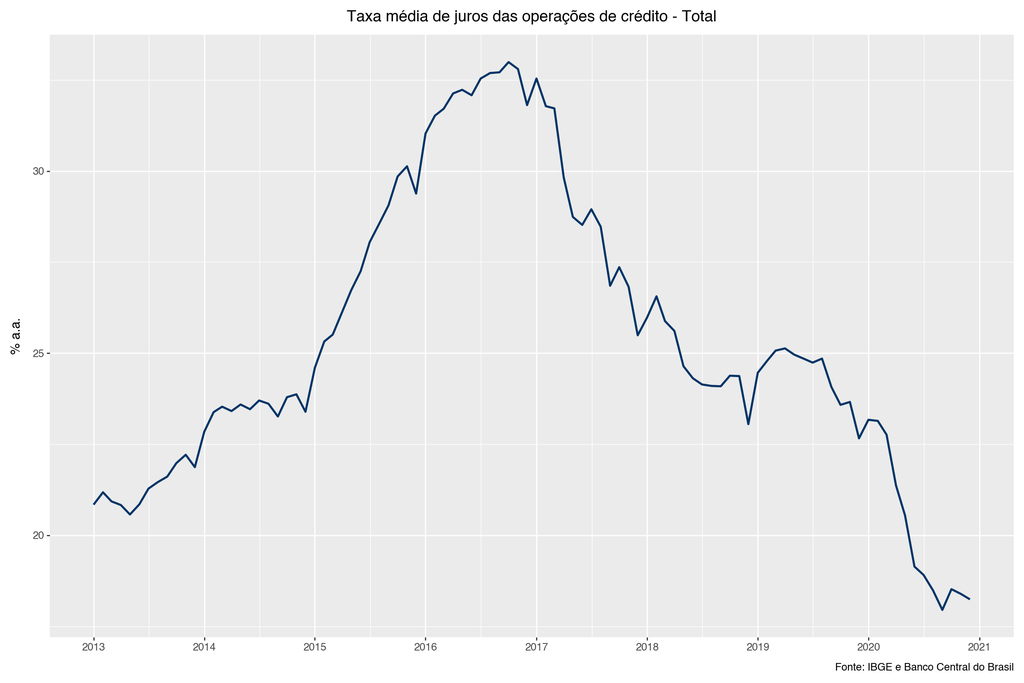

```python
# 2. Grapico para juros_medio
plot = (
    ggplot(concessoes) +
    aes(x='Date', y='juros_medio') +
    geom_line(size=1, color='#003366') +
    labs(
        x="",
        y="% a.a.",
        title="Taxa média de juros das operações de crédito - Total",
        caption="Fonte: IBGE e Banco Central do Brasil"
    ) +
    scale_x_datetime(
        breaks='1 year',
        labels=lambda l: [d.strftime('%Y') for d in l]
    ) +
    p9.theme(
        figure_size=(12, 8)  # Width, Height
    )
)

# Show plot
plot.show()
```

## Funçoes de Autocorrelação

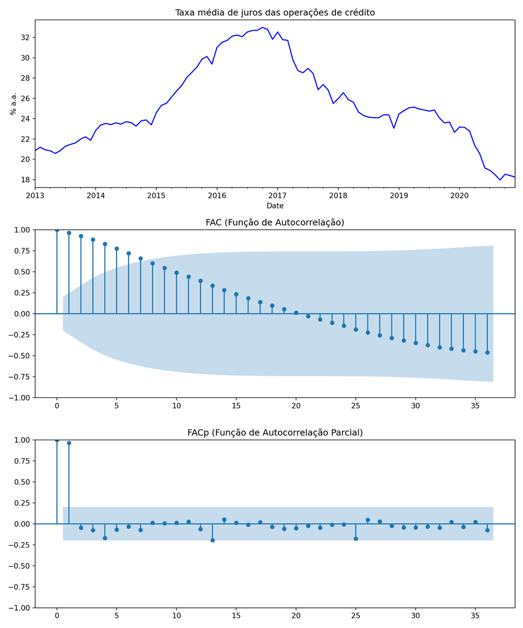

```python
# --- Prepara a série juros ---
juros = concessoes['juros_medio'].copy()
juros.index = concessoes['Date']  # coloca a Date como index
juros = juros.dropna()            # remove NaNs, se existirem

# --- Plota série, ACF e PACF ---
fig, axes = plt.subplots(3, 1, figsize=(10, 12))

# 1. Plota a série juros
juros.plot(ax=axes[0], title='Taxa média de juros das operações de crédito', color='blue')
axes[0].set_ylabel('% a.a.')

# 2. Plota ACF
plot_acf(juros, lags=36, ax=axes[1], title='FAC (Função de Autocorrelação)')

# 3. Plota PACF
plot_pacf(juros, lags=36, ax=axes[2], title='FACp (Função de Autocorrelação Parcial)', method='ywm')

plt.tight_layout()
plt.show()
```

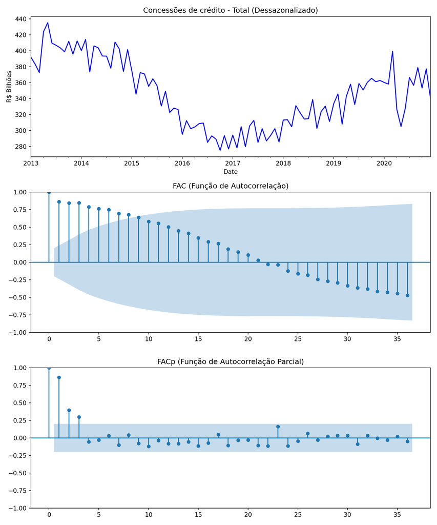

```python
# --- Prepara a série credito_total ---
credito = concessoes['credito_total'].copy()
credito.index = concessoes['Date']  # coloca a Date como index
credito = credito.dropna()

# Decomposição para retirar sazonalidade
decomp = seasonal_decompose(credito / 1000, model='additive', period=12)
credito_seas = (credito / 1000) - decomp.seasonal

# --- Plota série, ACF e PACF ---
fig, axes = plt.subplots(3, 1, figsize=(10, 12))

# 1. Plota a série de crédito dessazonalizada
credito_seas.plot(ax=axes[0], title='Concessões de crédito - Total (Dessazonalizado)', color='blue')
axes[0].set_ylabel('R$ Bilhões')

# 2. Plota ACF
plot_acf(credito_seas.dropna(), lags=36, ax=axes[1], title='FAC (Função de Autocorrelação)')

# 3. Plota PACF
plot_pacf(credito_seas.dropna(), lags=36, ax=axes[2], title='FACp (Função de Autocorrelação Parcial)', method='ywm')

plt.tight_layout()
plt.show()
```

## Teste de Raiz Unitária em nível

```python
# Executa o teste DF-GLS com seleção automática de defasagens
dfgls_juros = DFGLS(juros, lags=None, trend='ct')  # 'ct' para constante + tendência. Apenas c = constante.

# Exibe os resultados
print(dfgls_juros.summary())
```

```
      Dickey-Fuller GLS Results
=====================================
Test Statistic                 -1.750
P-value                         0.435
Lags                               12
-------------------------------------

Trend: Constant and Linear Time Trend
Critical Values: -3.67 (1%), -3.07 (5%), -2.78 (10%)
Null Hypothesis: The process contains a unit root.
Alternative Hypothesis: The process is weakly stationary.
```

```python
# Executa o teste DF-GLS com seleção automática de defasagens
dfgls_credito = DFGLS(credito_seas, lags=None, trend='ct')  # 'ct' para constante + tendência. Apenas c = constante.

# Exibe os resultados
print(dfgls_credito.summary())
```

```
      Dickey-Fuller GLS Results
=====================================
Test Statistic                 -1.021
P-value                         0.827
Lags                                2
-------------------------------------

Trend: Constant and Linear Time Trend
Critical Values: -3.64 (1%), -3.05 (5%), -2.76 (10%)
Null Hypothesis: The process contains a unit root.
Alternative Hypothesis: The process is weakly stationary.
```

## Diferenciação das séries

```python
diff1_juros = juros.diff(1)
diff1_credito = credito_seas.diff(1)

# Remover o primeiro valor (NaN gerado pela diferença)
diff1_juros = diff1_juros.dropna()
diff1_credito = diff1_credito.dropna()
```

## Funçoes de Autocorrelação das séries na 1 Diferença

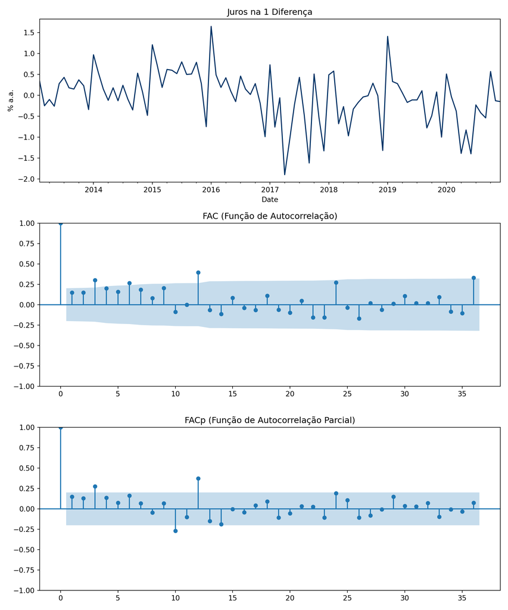

```python
# --- Plota série, ACF e PACF ---
fig, axes = plt.subplots(3, 1, figsize=(10, 12))

# 1. Plota a série juros
diff1_juros.plot(ax=axes[0], title='Juros na 1 Diferença', color='#003366')
axes[0].set_ylabel('% a.a.')

# 2. Plota ACF
plot_acf(diff1_juros, lags=36, ax=axes[1], title='FAC (Função de Autocorrelação)')

# 3. Plota PACF
plot_pacf(diff1_juros, lags=36, ax=axes[2], title='FACp (Função de Autocorrelação Parcial)', method='ywm')

plt.tight_layout()
plt.show()
```

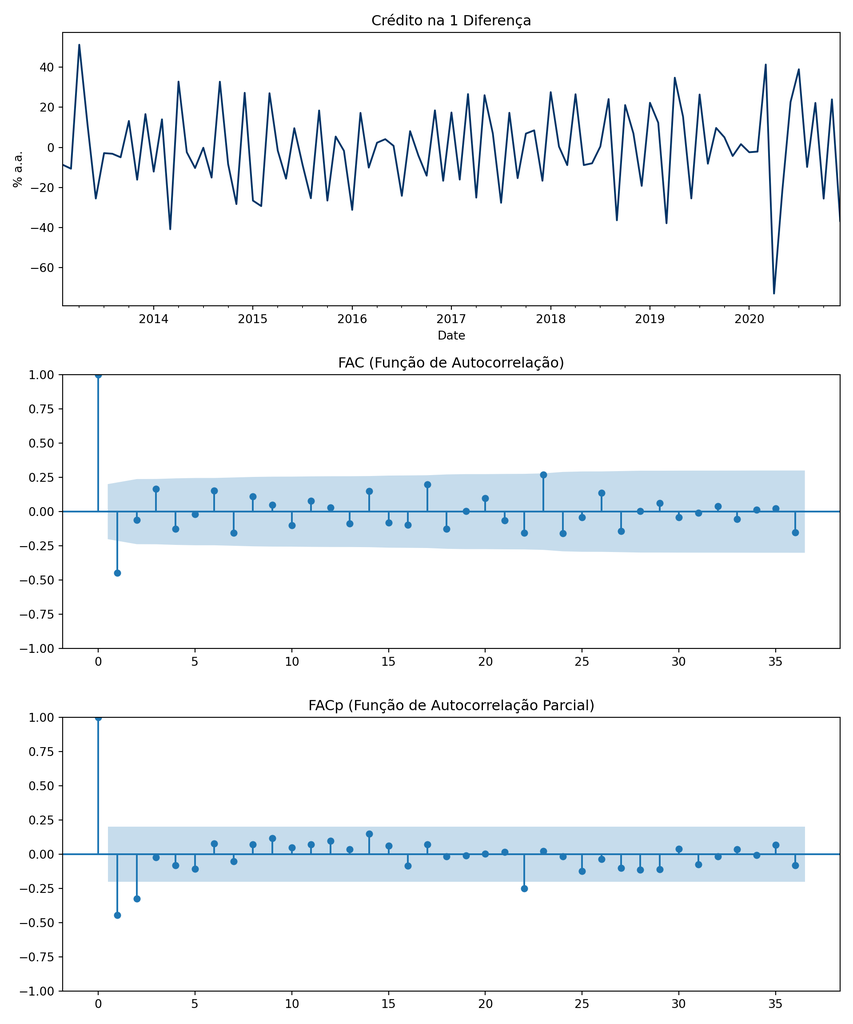

```python
# --- Plota série, ACF e PACF ---
fig, axes = plt.subplots(3, 1, figsize=(10, 12))

# 1. Plota a série juros
diff1_credito.plot(ax=axes[0], title='Crédito na 1 Diferença', color='#003366')
axes[0].set_ylabel('% a.a.')

# 2. Plota ACF
plot_acf(diff1_credito, lags=36, ax=axes[1], title='FAC (Função de Autocorrelação)')

# 3. Plota PACF
plot_pacf(diff1_credito, lags=36, ax=axes[2], title='FACp (Função de Autocorrelação Parcial)', method='ywm')

plt.tight_layout()
plt.show()
```

## Teste de Raiz Unitária na 1 diferença

```python
# Executa o teste DF-GLS com seleção automática de defasagens
dfgls_juros1 = DFGLS(diff1_juros, lags=2, trend='c')  # 'ct' para constante + tendência. Apenas c = constante.

# Exibe os resultados
print(dfgls_juros1.summary())
```

```
      Dickey-Fuller GLS Results
=====================================
Test Statistic                 -3.089
P-value                         0.002
Lags                                2
-------------------------------------

Trend: Constant
Critical Values: -2.77 (1%), -2.15 (5%), -1.84 (10%)
Null Hypothesis: The process contains a unit root.
Alternative Hypothesis: The process is weakly stationary.
```

```python
# Executa o teste DF-GLS com seleção automática de defasagens
dfgls_credito1 = DFGLS(diff1_credito, lags=2, trend='c')  # 'ct' para constante + tendência. Apenas c = constante.

# Exibe os resultados
print(dfgls_credito1.summary())
```

```
      Dickey-Fuller GLS Results
=====================================
Test Statistic                 -4.947
P-value                         0.000
Lags                                2
-------------------------------------

Trend: Constant
Critical Values: -2.77 (1%), -2.15 (5%), -1.84 (10%)
Null Hypothesis: The process contains a unit root.
Alternative Hypothesis: The process is weakly stationary.
```

Em Resumo: As duas séries possuem raiz unitária em nível, mas são estacionárias na primeira diferença, ou seja, são I(1). Então, as duas séries são integradas de mesma ordem. Se a combinação linear entre as duas for estacionário, elas serão cointegradas. Isto significa que existe uma relação de longo prazo entre elas.

# Estimação da regressão de Longo Prazo

```python
# Regressão do crédito sobre juros
X = sm.add_constant(juros)           # adiciona intercepto
regressao1 = sm.OLS(credito_seas, X).fit()

# Resultado da regressão
print(regressao1.summary())
```

```
                            OLS Regression Results
==============================================================================
Dep. Variable:                   None   R-squared:                       0.475
Model:                            OLS   Adj. R-squared:                  0.470
Method:                 Least Squares   F-statistic:                     85.10
Date:                Qua, 30 Abr 2025   Prob (F-statistic):           8.19e-15
Time:                        14:54:55   Log-Likelihood:                -463.50
No. Observations:                  96   AIC:                             931.0
Df Residuals:                      94   BIC:                             936.1
Df Model:                           1
Covariance Type:            nonrobust
===============================================================================
                  coef    std err          t      P>|t|      [0.025      0.975]
-------------------------------------------------------------------------------
const         527.8467     20.059     26.314      0.000     488.018     567.675
juros_medio    -7.2159      0.782     -9.225      0.000      -8.769      -5.663
==============================================================================
Omnibus:                        4.323   Durbin-Watson:                   0.524
Prob(Omnibus):                  0.115   Jarque-Bera (JB):                2.623
Skew:                          -0.193   Prob(JB):                        0.269
Kurtosis:                       2.288   Cond. No.                         165.
==============================================================================

Notes:
[1] Standard Errors assume that the covariance matrix of the errors is correctly specified.
```

o aumento dos juros reduz a concessão de crédito no longo prazo.

Os resíduos desta regressão podem ser submetidos a um teste de raiz unitária.

```python
# Extrai os resíduos da regressão
residuos = regressao1.resid

dfgls_residuos = DFGLS(residuos, lags=1, trend='c')
print(dfgls_residuos.summary())
```

```
      Dickey-Fuller GLS Results
=====================================
Test Statistic                 -1.935
P-value                         0.053
Lags                                1
-------------------------------------

Trend: Constant
Critical Values: -2.77 (1%), -2.15 (5%), -1.84 (10%)
Null Hypothesis: The process contains a unit root.
Alternative Hypothesis: The process is weakly stationary.
```

Os resíduos da regressão são estacionários, ou seja, I(0), considerando um nível de significância de 10%. Então, apesar das séries apresentarem tendencias estocásticas, a combinação linear delas (resíduo) é I(0).

O resultado disto é que a regressão passa a ter sentido e dizemos que as duas variáveis são co-integradas, ou seja, existe entre elas uma relação de equilíbrio de longo prazo.

## Estimação do Mecanismo de Correção de Erro

```python
# 1. Termo de correção de erro: lag do resíduo da regressão em nível
ec_lag = residuos.shift(1).dropna()

# 1. Alinhar os dados
ecm_data = pd.concat([diff1_credito, diff1_juros, ec_lag], axis=1).dropna()
ecm_data.columns = ['delta_credito', 'delta_juros', 'ec_lag']

# 3. Estima o modelo ECM
X = sm.add_constant(ecm_data[['delta_juros', 'ec_lag']])
y = ecm_data['delta_credito']
modelo_ecm = sm.OLS(y, X).fit()

# 4. Resultado
print(modelo_ecm.summary())
```

```
                            OLS Regression Results
==============================================================================
Dep. Variable:          delta_credito   R-squared:                       0.179
Model:                            OLS   Adj. R-squared:                  0.161
Method:                 Least Squares   F-statistic:                     10.03
Date:                Qua, 30 Abr 2025   Prob (F-statistic):           0.000115
Time:                        14:54:56   Log-Likelihood:                -417.21
No. Observations:                  95   AIC:                             840.4
Df Residuals:                      92   BIC:                             848.1
Df Model:                           2
Covariance Type:            nonrobust
===============================================================================
                  coef    std err          t      P>|t|      [0.025      0.975]
-------------------------------------------------------------------------------
const          -0.2552      2.041     -0.125      0.901      -4.308       3.798
delta_juros     3.6658      3.349      1.094      0.277      -2.986      10.318
ec_lag         -0.3181      0.071     -4.476      0.000      -0.459      -0.177
==============================================================================
Omnibus:                        1.025   Durbin-Watson:                   2.505
Prob(Omnibus):                  0.599   Jarque-Bera (JB):                0.566
Skew:                          -0.144   Prob(JB):                        0.754
Kurtosis:                       3.244   Cond. No.                         49.1
==============================================================================

Notes:
[1] Standard Errors assume that the covariance matrix of the errors is correctly specified.
```

Como pode ser observado, a estimativa de u(-1) é negativo. Isto significa que Y está acima do equilíbrio e começará a cair no período seguinte para retornar ao equilíbrio. A interpretação é que 31,81 % da discrepância entre as duas variáveis no mês anterior é eliminado no mês atual.

Quando a concessão de crédito está acima do nível de equilíbrio esperado pela relação com os juros, ela tende a cair nos meses seguintes — e vice-versa.